# Project Description

Rhea Bhat, Yaashi Khatri, Ian Wood, Neha George, Natalie Nguyen, Andrea Flores, Hiba Ansari

2022-10-13

#### rb43853, yak264, nmg2337, nmn498, ha9982, agf646, ipw89

## Project Description: Estimation of Obesity Levels

According to WHO, being overweight or obese is defined as abnormal or excessive fat accumulation that presents a risk to health. A body mass index (BMI) over 25 is considered overweight, and over 30 is obese. The issue has grown to epidemic proportions, with over 4 million people dying each year as a result of being overweight or obese in 2017 according to the global burden of disease.(WHO, 2021). As a result, the collaborative efforts to understand overweight and obesity and to promote healthy weight is an area to be researched on. In line with this, this project aims at predicting the obesity level of individuals. The dataset under study includes data for the estimation of obesity levels in individuals based on their eating habits and physical condition in Mexico, Peru ,and Columbia. The data contains 17 attributes and 2111 individuals aged 14 to 61. The 17 attributes are related to individual habits that are likely to determine obesity levels, such as number of main meals, time using technology devices, gender, and transportation used. The 2111 individuals are labeled with the class variable NObeyesdad (Obesity Level), that allows classification of the data using the values of Insufficient Weight (under Weight), Normal Weight, Overweight Level I, Overweight Level II, Obesity Type I, Obesity Type II and Obesity Type III. 77% of the data was generated synthetically using the Weka tool and the SMOTE filter, 23% of the data was collected directly from users through a web platform.

### Project Goals

We want to examine the effect of eating habits and physical conditions on obesity levels in Mexico, Peru, and Colombia. We will utilize a multiple regression model to examine these effects.

We will calculate the coefficient of determination (R^2 value) to judge the linearity of the data by: Exploring the relationship between various lifestyle choices (i.e transportation, smoking, etc.) and their weight classification

### Background

**Factors Contributing to Obesity**

Obesity is a disease characterized by an excessive accumulation of body fat that poses a risk to the individual’s health. The tool for measuring whether an individual is overweight or obese is through body mass index (BMI), in which a BMI of 25-29.9 kg/m^2 indicates being overweight and a BMI $>$ 30 indicates obesity (Fock & Khoo, 2013). There are a multitude of factors that contribute to the development of obesity. Among these factors include diet, physical conditions, and family history.

- *Diet*

  An imbalanced diet is the main contributing factor to the onset of obesity. Individuals that subscribe to diets with higher intakes in saturated and trans fat, refined grains, red meats, sweets, and sweetened sugary-beverages are observed to have increased weight gain and risk of obesity. Conversely, individuals with diets high in whole grains, vegetables, fruit, yogurt, nuts, fish, and poultry were observed to have less weight gain and decreased risk of obesity (Hruby et al., 2016).
- *Physical Conditions*

  Physical conditions refer to exercise, sedentary vs. active lifestyle, and sleep quality. According to a study conducted by Hruby et al. (2016), higher levels of physical activity (defined as activity $\ge$ 30 min/day) resulted in less weight gained than low physical activity levels (defined as activity $\le$ 30 min/day). Conversely, greater times spent engaged in sedentary activities (watching TV, using cellphone, playing video games, etc.) results in increased risk of obesity. The built environment of individuals may influence BMI as well. Higher density areas that are more walkable are likely to promote walking or bicycling as a means of transportation, which would increase average physical activity in these areas (Hruby et al., 2016).

  Sleep duration and quality also impacts risk of weight gain. It was found that short duration sleep (time slept $\le$ 6 hr per night) and poor sleep quality are linked to increased risk of obesity (Beccuti & Pannain, 2011).
- *Family History*

  Family history also contributes to the development of obesity and consists genetic factors and home environment. Genetics may impact dietary palate, food sensitivity, and metabolism of individuals. Variations in these genes could result in adverse eating choices (i.e., selective, limited, or excessive intake of different food groups). Moreover, Families of varying ethnic and cultural backgrounds are exposed to different types of diets that emphasize different food groups. Family environment also influences eating behaviors, which determines diet quality and quantity. The home environment determines if food is provided consistently, prepared at home, and if it is healthy and nutritious (Fruh, 2017).

### Visualization

```r
#Loading the data
library(tidyverse)
library(readxl)
obesityData <- read_excel("~/proj/obesityData.xlsx")
```

#### Before creating a visualization, here is a glimpse of the data

```r
# Converting
odata <- as.data.frame(obesityData)
glimpse(odata)
```

```
## Rows: 2,111
## Columns: 17
## $ Gender                         <chr> "Female", "Female", "Male", "Male", "Ma…
## $ Age                            <dbl> 21, 21, 23, 27, 22, 29, 23, 22, 24, 22,…
## $ Height                         <dbl> 1.62, 1.52, 1.80, 1.80, 1.78, 1.62, 1.5…
## $ Weight                         <dbl> 64.0, 56.0, 77.0, 87.0, 89.8, 53.0, 55.…
## $ family_history_with_overweight <chr> "yes", "yes", "yes", "no", "no", "no", …
## $ FAVC                           <chr> "no", "no", "no", "no", "no", "yes", "y…
## $ FCVC                           <dbl> 2, 3, 2, 3, 2, 2, 3, 2, 3, 2, 3, 2, 3, …
## $ NCP                            <dbl> 3, 3, 3, 3, 1, 3, 3, 3, 3, 3, 3, 3, 3, …
## $ CAEC                           <chr> "Sometimes", "Sometimes", "Sometimes", …
## $ SMOKE                          <chr> "no", "yes", "no", "no", "no", "no", "n…
## $ CH2O                           <dbl> 2, 3, 2, 2, 2, 2, 2, 2, 2, 2, 3, 2, 3, …
## $ SCC                            <chr> "no", "yes", "no", "no", "no", "no", "n…
## $ FAF                            <dbl> 0, 3, 2, 2, 0, 0, 1, 3, 1, 1, 2, 2, 2, …
## $ TUE                            <dbl> 1, 0, 1, 0, 0, 0, 0, 0, 1, 1, 2, 1, 0, …
## $ CALC                           <chr> "no", "Sometimes", "Frequently", "Frequ…
## $ MTRANS                         <chr> "Public_Transportation", "Public_Transp…
## $ NObeyesdad                     <chr> "Normal_Weight", "Normal_Weight", "Norm…
```

#### Below are a few visualizations that help us better understand the data

[figure not shown]

```r
odata %>% group_by(Age) %>% ggplot(aes(x=NObeyesdad, y=Weight, color=Gender)) + geom_bar(stat="identity") + xlab("Weight Classification") + ylab("Weight (in lbs) ")+ ggtitle("Bar Plot: Weight vs. Classification") + scale_x_discrete(guide = guide_axis(n.dodge=2))
```

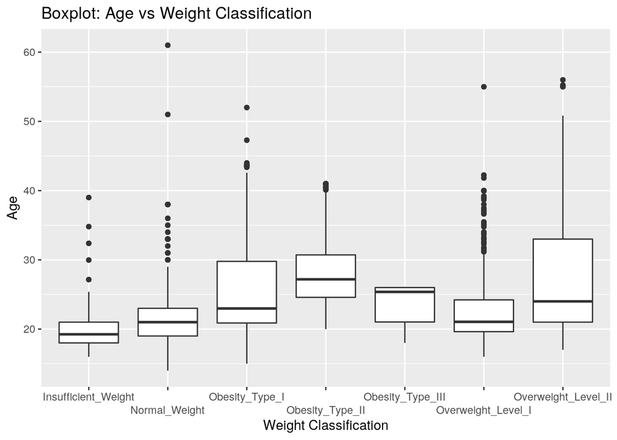

```r
ggplot(odata) + geom_boxplot(aes(x=NObeyesdad, y=Age))+ xlab("Weight Classification") + ylab("Age") + ggtitle("Boxplot: Age vs Weight Classification")+ scale_x_discrete(guide = guide_axis(n.dodge=2))
```

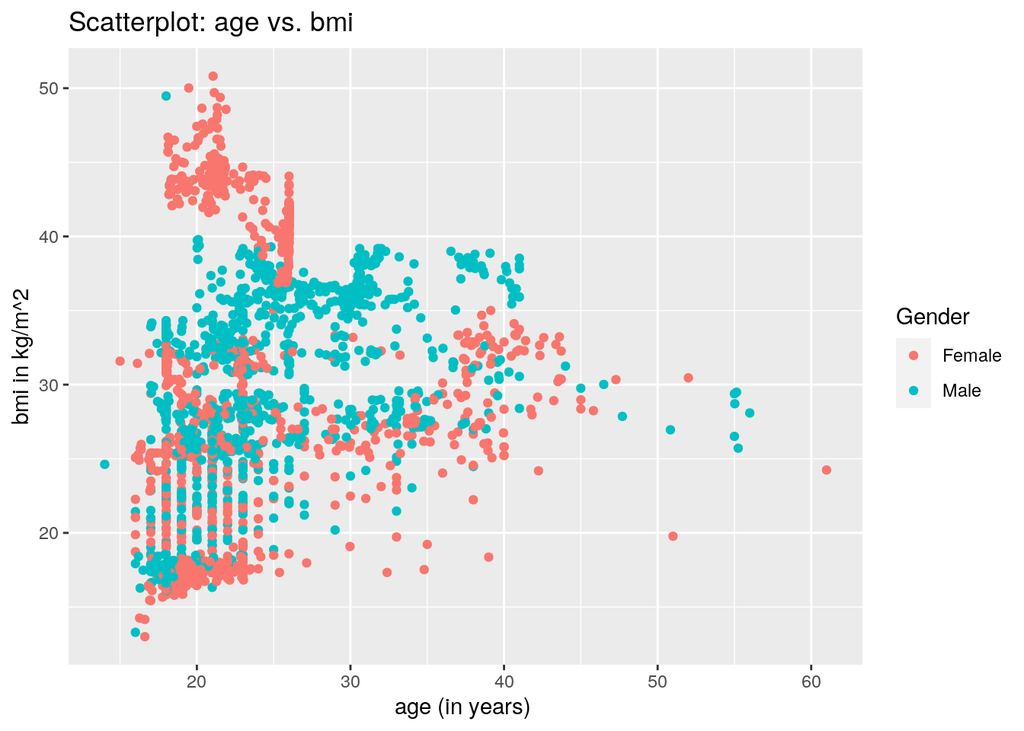

```r
odata <- odata %>% mutate(bmi = Weight / (Height)^2)
odata %>% ggplot() + geom_point(aes(x = Age, y = bmi, color= Gender)) + ylab("bmi in kg/m^2") + xlab("age (in years) ")+ ggtitle("Scatterplot: age vs. bmi")
```

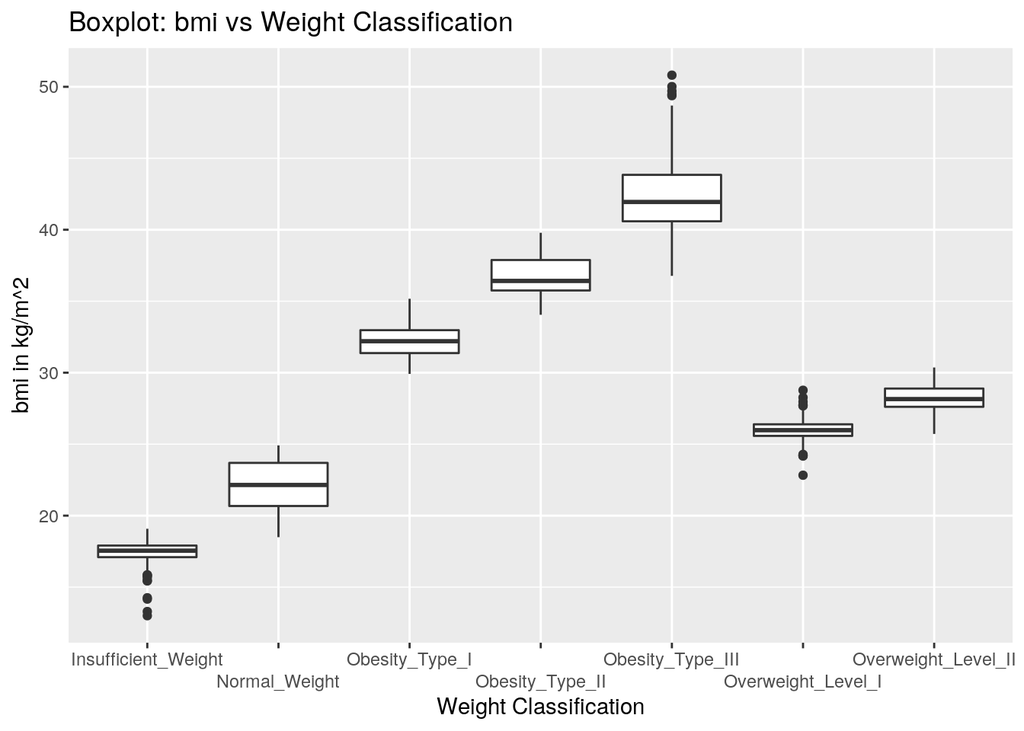

```r
ggplot(odata) + geom_boxplot(aes(x=NObeyesdad, y=bmi))+ xlab("Weight Classification") + ylab("bmi in kg/m^2") + ggtitle("Boxplot: bmi vs Weight Classification")+ scale_x_discrete(guide = guide_axis(n.dodge=2))
```

#### Links

https://archive.ics.uci.edu/ml/machine-learning-databases/00544/

https://www.ncbi.nlm.nih.gov/pmc/articles/PMC6710633/

#### References

World Health Organization. (n.d.). Obesity and overweight. World Health Organization. Retrieved October 11, 2022, from https://www.who.int/news-room/fact-sheets/detail/obesity-and-overweight

Beccuti, G., & Pannain, S. (2011). Sleep and obesity: Current Opinion in Clinical Nutrition and Metabolic Care, 14(4), 402–412. https://doi.org/10.1097/MCO.0b013e3283479109

Fock, K. M., & Khoo, J. (2013). Diet and exercise in management of obesity and overweight: Diet and exercise for weight management. Journal of Gastroenterology and Hepatology, 28, 59–63. https://doi.org/10.1111/jgh.12407

Fruh, S. M. (2017). Obesity: Risk factors, complications, and strategies for sustainable long‐term weight management. Journal of the American Association of Nurse Practitioners, 29(S1), S3–S14. https://doi.org/10.1002/2327-6924.12510

Hruby, A., Manson, J. E., Qi, L., Malik, V. S., Rimm, E. B., Sun, Q., Willett, W. C., & Hu, F. B. (2016). Determinants and consequences of obesity. American Journal of Public Health, 106(9), 1656–1662. https://doi.org/10.2105/AJPH.2016.303326

Palechor, F. M., & Manotas, A. de la H. (2019). Dataset for estimation of obesity levels based on eating habits and physical condition in individuals from Colombia, Peru and Mexico. Data in Brief, 25, 104344. https://doi.org/10.1016/j.dib.2019.104344